# Name: N.Kushal Kumar

# Reg.no: 21BCE9778

# Assignment-2

1.Take car_crashes dataset from seaborn library  
2.load the dataset  
3.Perfrom Data Visualization  
4.Inference is must for each and every graph

```python
import seaborn as sns
data = sns.load_dataset('car_crashes')
```

```python
data.head()
```

|  | total | speeding | alcohol | not_distracted | no_previous | ins_premium | ins_losses | abbrev |
| --- | --- | --- | --- | --- | --- | --- | --- | --- |
| 0 | 18.8 | 7.332 | 5.640 | 18.048 | 15.040 | 784.55 | 145.08 | AL |
| 1 | 18.1 | 7.421 | 4.525 | 16.290 | 17.014 | 1053.48 | 133.93 | AK |
| 2 | 18.6 | 6.510 | 5.208 | 15.624 | 17.856 | 899.47 | 110.35 | AZ |
| 3 | 22.4 | 4.032 | 5.824 | 21.056 | 21.280 | 827.34 | 142.39 | AR |
| 4 | 12.0 | 4.200 | 3.360 | 10.920 | 10.680 | 878.41 | 165.63 | CA |

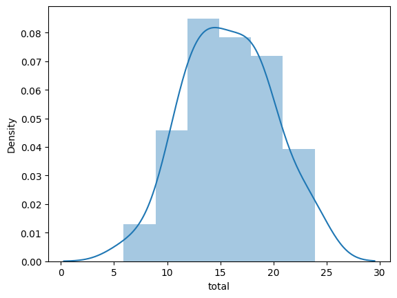

```python
sns.distplot(data['total'])
```

Inference: distplot() plots a univariate distribution of observations. The above graph depicts the variation in the distribution of the data of 'total' column. It shows the density of total values is highest between 10-15 around 13 and least between 5-10.

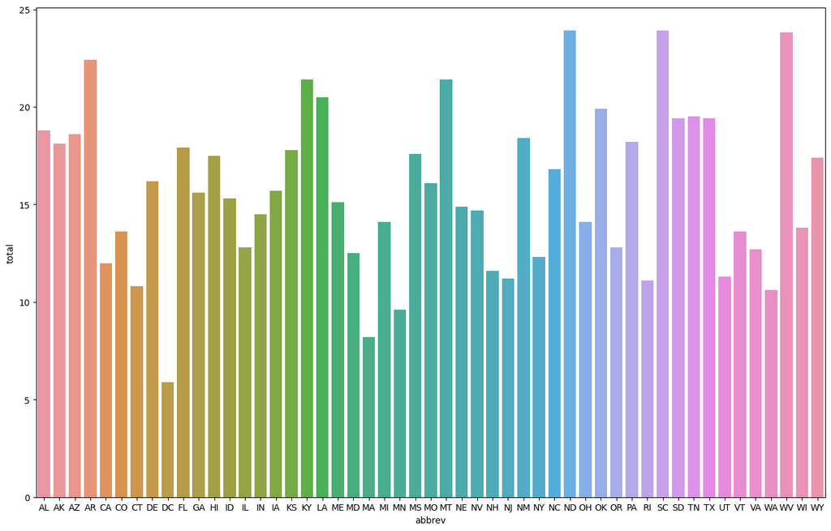

```python
import matplotlib.pyplot as plt
plt.subplots(figsize=(16,10))
sns.barplot(x='abbrev',y= 'total',data=data)
```

Inference: The Above Graph shows the bar plot of vaious abbrevations. The value of total is highest at 'ND' and lowest at 'DC'.

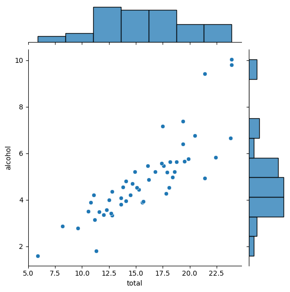

```python
sns.jointplot(x='total',y='alcohol',data=data)
```

Inference: The above join plot shows the impact of alchohol on car crashes through scatter plot and bar plots

[output not shown]

[output cut: 159 more lines]

[output not shown]

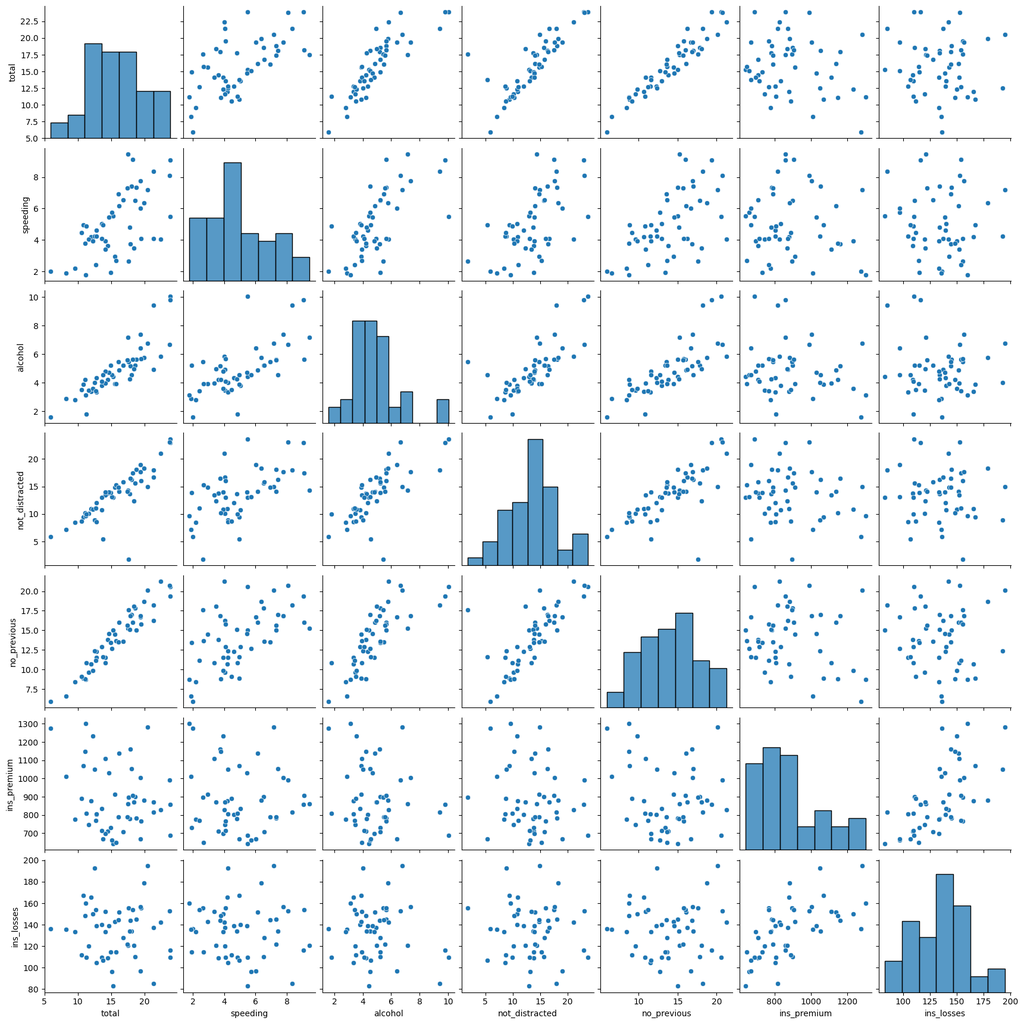

```python
sns.pairplot(data)
```

Inference: The above graph shows the various combinations of scatter plot to identify the effect of each factor with respect to other factors.

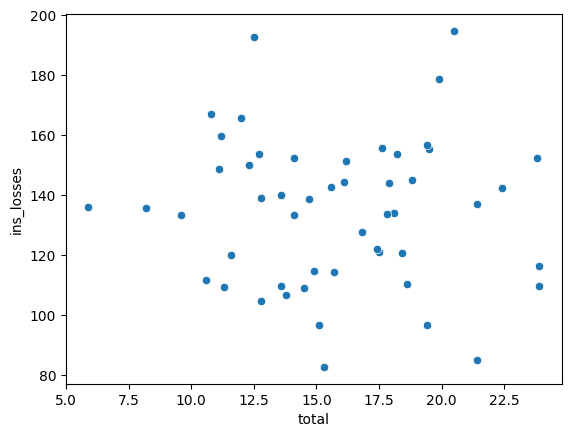

```python
sns.scatterplot(x="total",y="ins_losses",data=data)
```

Inference: The Above graph is a scatter plot that is used to plot the values of total car crashes with respect to insurance losses by showning the correlation between them.

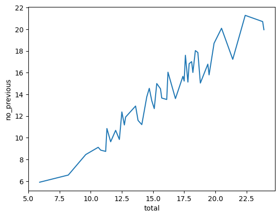

```python
sns.lineplot(x="total",y="no_previous",data=data,ci=None)
```

Inference: This graph clearly shows how total crashes vary acccording to the 'no_previous' feature. As there are outliers in the data we can find the improper graph

```python
adj_data = data.drop('abbrev',axis=1)
corr = adj_data.corr()
corr
```

|  | total | speeding | alcohol | not_distracted | no_previous | ins_premium | ins_losses |
| --- | --- | --- | --- | --- | --- | --- | --- |
| total | 1.000000 | 0.611548 | 0.852613 | 0.827560 | 0.956179 | -0.199702 | -0.036011 |
| speeding | 0.611548 | 1.000000 | 0.669719 | 0.588010 | 0.571976 | -0.077675 | -0.065928 |
| alcohol | 0.852613 | 0.669719 | 1.000000 | 0.732816 | 0.783520 | -0.170612 | -0.112547 |
| not_distracted | 0.827560 | 0.588010 | 0.732816 | 1.000000 | 0.747307 | -0.174856 | -0.075970 |
| no_previous | 0.956179 | 0.571976 | 0.783520 | 0.747307 | 1.000000 | -0.156895 | -0.006359 |
| ins_premium | -0.199702 | -0.077675 | -0.170612 | -0.174856 | -0.156895 | 1.000000 | 0.623116 |
| ins_losses | -0.036011 | -0.065928 | -0.112547 | -0.075970 | -0.006359 | 0.623116 | 1.000000 |

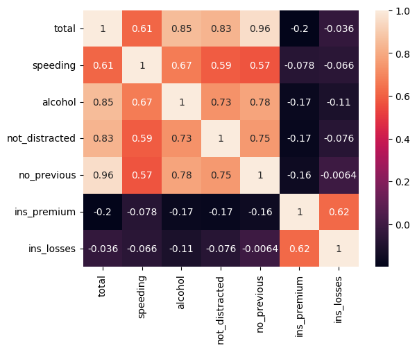

```python
sns.heatmap(corr,annot=True)
```

Inference: The above heat map shows the correlation between every two feature with a scale and indicates that 'no_previous' feature and 'total' feature are highly correlated.

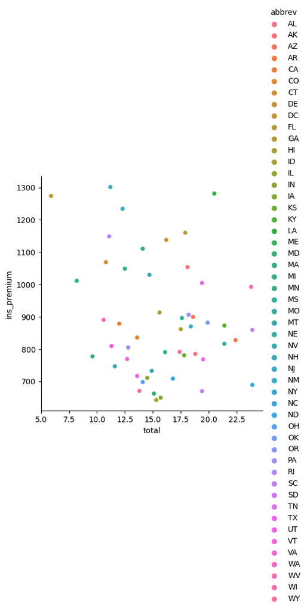

```python
sns.relplot(x="total",y="ins_premium",data=data,hue="abbrev")
```

Inference: This is a relative plot between 'ins_premium' and 'total' features by categorizing data with respect to 'abbrev' feature